# テキスト分析ワークショップ

2019-9-1 (updated: 2019-09-24)

## 自己紹介

- 松尾晃孝 (Akitaka Matsuo)
- Postdoctraol Fellow at Institute for Data Science and Analytics (IADS) and Department of Government, University of Essex
- quanteda develope team member
  - core developer of [spacyr](https://spacyr.quanteda.io/)
- 専門: 政治学方法論、テキスト分析、議会政治、比較政治
- web:
  - website: https://amatsuo.net
  - github: https://github.com/amatsuo

## 自己紹介

- 名前
- 所属
- テキスト分析への関心
  - 経験
  - 使いたいデータ

## 今日の予定

1. 自己紹介
2. 必要なソフトウェアのインストール
3. データをRに読み込む
4. Rデータをquanteda形式へと変換する
5. quantedaでテキスト分析: 記述統計
6. quantedaでテキスト分析: モデルを使って分析
7. (おまけ) Word vectorの推定

## 必要なソフトウェアのインストール

- R, RStudio (https://qiita.com/hujuu/items/ddd66ae8e6f3f989f2c0)
- r-packages
  - tidyverse
  - quanteda (https://quanteda.io/articles/pkgdown/quickstart_ja.html)
  - caret (machine learning utility)
  - e1071 (confusionMatrix function)
  - DT (html table generation)
  - text2vec (word embedding)

## 必要なソフトウェアのインストール

1. R: 統計分析ソフトウェア
2. RStudio:
   - Rを使うための統合開発環境
   - 事実上のスタンダード

## データおよびスライドのダウンロード

- このワークショップで使うファイルは、すべてこのgithubのリポジトリにまとめてある https://github.com/amatsuo/Kyoto-Workshop-2019
- RStudioでプロジェクトiconをクリック
  - [New Project]->[Version Control]->[Git]
  - 上記のURLを入力
- これでワークショップのリポジトリをダウンロードして、RStudioのプロジェクトとして登録できた

[figure not shown]

gitインストールしていない場合は、以下からインストールする

https://git-scm.com/downloads

あるいは上記のurlからダウンロードを選択して、zipファイルをダウンロード

## 必要なパッケージ

1. tidyverse
   - https://www.tidyverse.org/
   - “The tidyverse is an opinionated collection of R packages designed for data science.”
   - インストールコマンド

   ```r
   install.packages("tidyverse")
   ```

2. quanteda
   - テキスト分析を統合的に行うためのRパッケージ
   - インストールコマンド

   ```r
   install.packages("quanteda")
   ```

3. その他

   ```r
   install.packages(c("caret", "e1071", "DT", "text2vec"))
   ```

## テキストデータをRに読み込む

**パッケージをロードする**

```r
library(tidyverse)
library(quanteda)
library(stringi)
library(caret)
library(DT)
```

## テキストデータをRに読み込む

- データはすべて、`data`フォルダに入っている
- これはIMFとAMROのカントリーレポートをpdfから抽出したもの

**ファイルをまずリストしてみる**

```r
list.files("data", pattern = "csv")
```

```
##  [1] "AMRO-Indonesia-2018.csv" "AMRO-Japan-2018.csv"
##  [3] "AMRO-Korea-2018.csv"     "AMRO-Thailand-2018.csv"
##  [5] "AMRO-Vietnum-2017.csv"   "IMF-Indonesia-2018.csv"
##  [7] "IMF-Indonesia-2019.csv"  "IMF-Japan-2018.csv"
##  [9] "IMF-Korea-2018.csv"      "IMF-Thailand-2018.csv"
## [11] "IMF-Vietnum-2018.csv"
```

- 11のファイル、`{InternationalOrganization}-{Country}-{year}.csv`という規則のファイル名

## テキストデータをRに読み込む

### ファイルの中身の確認

```r
data_temp <- read_csv("data/AMRO-Korea-2018.csv") # データを開く
print(data_temp) # 画面にプリントしてみる
```

```
## # A tibble: 1,514 x 5
##    page_number paragraph_number text                pages_to_skip detection
##          <dbl>            <dbl> <chr>               <lgl>         <chr>
##  1           1                1 <NA>                TRUE          empty
##  2           1                2 <NA>                TRUE          empty
##  3           1                3 ASEAN+3 Macroecono… TRUE          page_foo…
##  4           1                4 <NA>                TRUE          empty
##  5           1                5 <NA>                TRUE          empty
##  6           1                6 AMRO Annual Consul… TRUE          normal
##  7           1                7 Korea - 2018        TRUE          normal
##  8           1                8 <NA>                TRUE          empty
##  9           1                9 <NA>                TRUE          empty
## 10           1               10 <NA>                TRUE          empty
## # … with 1,504 more rows
```

レポートのpdfを色々と事前加工したものがそれぞれのファイルに入っている。ここから、余計な行や列を消して、必要な部分を取り出す。

## テキストデータをRに読み込む

### データの加工

- 使いたい変数は`page_number, paragraph_number, text`
- 行の削除には`pages_to_skip, detection`の変数の値を使う

**`dplyr`を使ったデータフレームの加工**

```r
# "#"以降はコメント

data_temp <- data_temp %>% # "%>%"はdplyrのchaining command
  filter(pages_to_skip != TRUE) %>% # 列をフィルターする。スキップするページの削除
  # チェインはいくつも繋げられる
  filter(detection == "normal") %>% # ノーマルテキストの行を選択
  select(page_number, paragraph_number, text)
print(data_temp)
```

```
## # A tibble: 564 x 3
##    page_number paragraph_number text
##          <dbl>            <dbl> <chr>
##  1           4                4 Executive Summary
##  2           4                5 1. Korea’s economy is expected to grow at …
##  3           4                6 2. Headline inflation eased from 1.9 perce…
##  4           4                7 3. The economy is resilient to external sh…
##  5           4                8 4. The monetary policy stance remains acco…
##  6           4                9 5. In 2018, fiscal policy has been expansi…
##  7           4               10 6. Weaker-than-expected growth in China an…
##  8           4               11 7. Risks and vulnerability stemming from h…
##  9           5                4 risk from the debt build-up is not a conce…
## 10           5                5 8. Although the external sector remains ve…
## # … with 554 more rows
```

## テキストデータをRに読み込む

### たくさんのファイルの一括処理

これらの処理をまとめて一つのデータフレームに纏める いくつか方法があるが、３つ示す

##### 方法1: forループを使う方法

```r
data_all <- NULL # 空のデータを作る
file_names <- list.files("data", pattern = "csv", full.names = TRUE)

# mutate() を使って新しい変数を作成
for (fn in file_names) {
  data_current <- read_csv(fn) # データを開く
  data_current <- data_current %>% # "%>%"はdplyrのchaining command
    filter(pages_to_skip != TRUE) %>% # 列をフィルターする。スキップするページの削除
    filter(detection == "normal") %>% # ノーマルテキストの行を選択
    select(page_number, paragraph_number, text) %>%
    mutate(file_name = fn)
  data_all <- bind_rows(data_all, data_current) # data_all にdata_currentを結合
}
```

## テキストデータをRに読み込む

##### 方法2: lapply() + bind_rows()

```r
file_names <- list.files("data", pattern = "csv", full.names = TRUE)

process_each <- function(fn) {
  data_current <- read_csv(fn) # データを開く
  data_current <- data_current %>% # "%>%"はdplyrのchaining command
    filter(pages_to_skip != TRUE) %>% # 列をフィルターする。スキップするページの削除
    filter(detection == "normal") %>% # ノーマルテキストの行を選択
    select(page_number, paragraph_number, text) %>%
    mutate(file_name = fn)
  return(data_current)
}

data_all_2 <- lapply(file_names, process_each) %>% bind_rows()
```

## テキストデータをRに読み込む

### 方法3: readtextパッケージを使う

```r
library(readtext)
data_all_3 <-
  readtext("data", text_field = "text") %>% # すべてのファイルを読んで結合
  filter(pages_to_skip != TRUE) %>%
  filter(detection == "normal") %>%
  select(doc_id, page_number, paragraph_number, text) %>%
  rename(file_name = doc_id)
```

以上の方法いずれかで、csvに入っていたテキストデータを、Rデータフレームに格納することができた。

## テキストデータをRに読み込む

#### ファイル名から変数を取り出す

ここまで作成したデータは、国名などがデータとして入っていないので、これをファイル名の変数から取り出す。

```r
data_all <-
  data_all %>%
  # 一時変数のtmp作成
  mutate(tmp = file_name %>%
           stri_replace_first_fixed("data/", "") %>%
           stri_replace_first_fixed(".csv", "")) %>% # 余計な部分を消す
  separate(tmp, sep = "-", into = c("institution", "country", "year"))
　# dplyrのseparate()を使ってtmp列を３つの変数に分割
```

## Rデータをquanteda形式へと変換する

quantedaを使うと、Rのデータフレームを簡単にデータ分析で利用可能な形にできる

**ステップ**

1. コーパスの作成
2. テキストのトークン化(tokenization)
3. 文書特徴行列の作成 (document term matrix, dfm)

## コーパスの作成

**corpus**とは、テキストとテキストのメタ変数群を一緒に格納する**quanteda**のオブジェクト。Rのデータフレームから簡単に作成できる。コーパスを作る前にはテキストに手を加えないのが普通。ただし、段落単位のコーパスを文単位に分けたりはこの段階でする。

```r
data_corpus <- corpus(data_all, text_field = "text")
# text_fieldでテキストの変数名を指定
print(data_corpus)
```

```
## Corpus consisting of 6,041 documents and 6 docvars.
```

中身の確認をするには`texts()`コマンドを使う

```r
texts(data_corpus) %>% head(2) %>% print()
```

```
##                                                                                                                                                                                                                                                                                                          …
## "Executive Summary The Indonesian economy has been resilient against external headwinds, as growth is expected to remain robust and inflation contained in 2018. Recent policy mix recalibration with the implementation of \"pre-emptive, front-loading, and ahead-of-the-curve\" measures have focused …
##                                                                                                                                                                                                                                                                                                          …
##                                                                                                                                                                                                                                                                                                          …
```

### 文書変数(document variables)の取り出し

`corpus()`でデータフレームから作成されたコーパスは、すべての変数を保持していて、トークン化したり、dfmを作っても、その変数の受け継がれていく。取り出すためには`docvars()`コマンドを使う。

```r
docvars(data_corpus) %>% head()
```

```
##       page_number paragraph_number                    file_name
## text1           4                5 data/AMRO-Indonesia-2018.csv
## text2           4                6 data/AMRO-Indonesia-2018.csv
## text3           4                7 data/AMRO-Indonesia-2018.csv
## text4           4                8 data/AMRO-Indonesia-2018.csv
## text5           4                9 data/AMRO-Indonesia-2018.csv
## text6           4               10 data/AMRO-Indonesia-2018.csv
##       institution   country year
## text1        AMRO Indonesia 2018
## text2        AMRO Indonesia 2018
## text3        AMRO Indonesia 2018
## text4        AMRO Indonesia 2018
## text5        AMRO Indonesia 2018
## text6        AMRO Indonesia 2018
```

## コーパスの変形

`quanteda`はコーパスを作り変えるためのメソッドを`corpus_*()`という形で提供している。

#### テキストの単位を変える

段落から文単位に

```r
data_corpus_sentence <- corpus_reshape(data_corpus, to = 'sentences')
print(data_corpus_sentence)
```

```
## Corpus consisting of 14,687 documents and 6 docvars.
```

#### コーパスの一部の選択

`corpus_subset()`の二個目の引数がコーパスを選ぶ条件を指定。文書変数を直接使える。

```r
data_corpus_korea <- corpus_subset(data_corpus, country == 'Korea')
print(data_corpus_korea)
```

```
## Corpus consisting of 1,499 documents and 6 docvars.
```

## トークン化

**quanetda**では`tokens()`コマンドを使って、テキストをトークン化する。トークンの単位は色々あるが、基本的には単語単位に分けることが多い。

```r
data_tokens <- tokens(data_corpus)
data_tokens[1]
```

```
## tokens from 1 document.
## text1 :
##   [1] "Executive"          "Summary"            "The"
##   [4] "Indonesian"         "economy"            "has"
##   [7] "been"               "resilient"          "against"
##  [10] "external"           "headwinds"          ","
##  [13] "as"                 "growth"             "is"
##  [16] "expected"           "to"                 "remain"
##  [19] "robust"             "and"                "inflation"
##  [22] "contained"          "in"                 "2018"
##  [25] "."                  "Recent"             "policy"
##  [28] "mix"                "recalibration"      "with"
##  [31] "the"                "implementation"     "of"
##  [34] "\""                 "pre-emptive"        ","
##  [37] "front-loading"      ","                  "and"
```

[output cut: 44 more lines]

## 不必要なトークンの除去、トークンの整形

`tokens()`オブジェクトを作成する過程で、あるいは作成してから、必要に応じてトークンを整形できる。

作成時のオプションは基本的には全てオフになっているが、これをオンにすることでいろいろな操作ができる。

```r
tokens_temp <- tokens(data_corpus,
                      remove_numbers = FALSE,
                      remove_punct = FALSE,
                      remove_symbols = FALSE,
                      remove_separators = TRUE,
                      remove_twitter = FALSE,
                      remove_hyphens = FALSE,
                      remove_url = FALSE)
```

もしくは、`tokens_select()`を使って、より細かな操作ができる

```r
long_tokens <- tokens_select(data_tokens, min_nchar = 3)
number_tokens <- tokens_select(data_tokens, "^\\d", valuetype = "regex")
```

## KeyWord-In-Context (kwic)

**tokens**オブジェクトにkwicを適用することで、自分の興味ある単語が使われている文脈を抽出できる。例えば、“inflation targetting”。

```r
kwic(data_tokens, phrase("inflation targe*"))
```

```
##
##     [text256, 16:17]                   Bank of Japan's 2 percent |
##     [text326, 36:37]              achievability of the 2 percent |
##     [text326, 85:86]               over the achievability of the |
##     [text328, 84:85]                   for the current 2 percent |
##     [text329, 60:61]  strengthening commitments to achieving the |
##   [text477, 123:124]          investigating the optimal level of |
##     [text478, 23:24]              achievability of the 2 percent |
##     [text596, 17:18] ) Headline inflation Inflation expectations |
##       [text781, 1:2]                                             |
##    [text1165, 31:32]               , below the BOT's medium-term |
##  [text1165, 181:182]               months falls within the BOT's |
##    [text1257, 26:27]                     moving in line with the |
##    [text1284, 15:16]            has been below BOT's medium-term |
##    [text1702, 73:74]                    to the attainment of the |
##  [text2019, 101:102]                   to the achievement of the |
##    [text2153, 58:59]                         adopted in 2003. An |
##  [text2582, 126:127]            patient approach to reaching the |
##    [text2583, 83:84]            public support for achieving the |
##  [text2583, 101:102]                interest rate target and the |
##  [text2583, 137:138]      consider moving closer to full-fledged |
##      [text2592, 1:2]                                             |
##     [text2598, 9:10]          BoJ acknowledged that reaching the |
##    [text2704, 52:53]            patient approach to reaching the |
##    [text2704, 73:74]                interest rate target and the |
##  [text2704, 106:107]                          to a full- fledged |
##      [text2877, 1:2]                                             |
##    [text3364, 27:28] Inflation expectations re-anchored at BoJ's |
##      [text3767, 8:9]         MONETARY POLICY FRAMEWORK IN KOREA1 |
##    [text3767, 38:39]       inflation expectations fell below the |
##      [text3768, 6:7]                          1. The adoption of |
##    [text3768, 60:61]                            crisis( GFC) put |
##    [text3768, 79:80]               bottom of the 2.5-3.5 percent |
##  [text3768, 100:101]                     was replaced by a level |
##      [text3769, 7:8]                      . The reduction in the |
##    [text3769, 58:59]               a reassessment of the optimal |
##     [text3776, 9:10]             measure of the effectiveness of |
##      [text3777, 3:4]                                          4. |
##  [text3777, 104:105]              incentives to deviate from the |
##    [text3778, 11:12]        environment revealed areas where the |
```

[output cut: 83 more lines]

```
##   Inflation target   | Core inflation, Feb-2018(
##   Inflation Target   | and Core Inflation( Percent
##   inflation target   | , with macroprudential policy used
##   inflation target   | , while addressing financial stability
##   inflation target   | . Thailand: Financial Soundness
##   inflation target   | while using macroprudential policy to
##   inflation target   | . A flexible exchange rate
##  inflation targeting | framework, especially the need
##   inflation target   | and limiting financial vulnerabilities.
##   inflation target   | should be done flexibly,
##  inflation targeting | .
##  inflation targeting | . Banks must be strengthened
##  inflation targeting | and greater exchange rate flexibility
##  inflation targeting | , but the sequencing of
##  inflation targeting | and greater exchange rate flexibility
```

## 今回の分析の目的に合わせてtokensオブジェクトを作成する

```r
data_tokens_final <- tokens(data_corpus,
                      remove_numbers = TRUE,
                      remove_punct = FALSE,
                      remove_symbols = FALSE,
                      remove_separators = TRUE,
                      remove_twitter = FALSE,
                      remove_hyphens = FALSE,
                      remove_url = TRUE) %>%
  tokens_remove(pattern = stopwords(), padding = TRUE) %>% # ストップワードを消す
  tokens_remove(pattern = c("AMRO", "IMF"), padding = TRUE) %>% # 機関名を消す
  tokens_remove(pattern = c("Indonesia*", "Japan*", "Korea*", "Thai*", "Vietnum*"),
                padding = TRUE) %>% # 国名を消す
  tokens_keep(pattern = "^[a-zA-Z]+$", valuetype = "regex", padding = TRUE) # アルファベットだけでできた単語を残す

data_tokens_final[1]
```

```
## tokens from 1 document.
## text1 :
##   [1] "Executive"      "Summary"        ""               ""
##   [5] "economy"        ""               ""               "resilient"
##   [9] ""               "external"       "headwinds"      ""
##  [13] ""               "growth"         ""               "expected"
##  [17] ""               "remain"         "robust"         ""
##  [21] "inflation"      "contained"      ""               ""
##  [25] "Recent"         "policy"         "mix"            "recalibration"
##  [29] ""               ""               "implementation" ""
##  [33] ""               ""               ""               ""
##  [37] ""               ""               ""               ""
##  [41] "measures"       ""               "focused"        ""
##  [45] "maintaining"    "stability"      ""               "supporting"
##  [49] "growth"         ""               "Continued"      ""
```

[output cut: 27 more lines]

## コロケーションを見つける

コロケーションを計算してみる

```r
colloc <- textstat_collocations(data_tokens_final, min_count = 5, tolower = FALSE)
colloc %>%
  filter(collocation %>% stri_trans_tolower %>% stri_detect_fixed("inflation"))
```

```
##               collocation count count_nested length    lambda          z
## 1  inflation expectations    83            0      2 6.9178416 37.4655354
## 2        inflation target    44            0      2 4.9446693 28.4390691
## 3           CPI inflation    26            0      2 5.4951688 23.0433782
## 4       Inflation Primary    15            0      2 6.2999661 21.1390807
## 5      Headline inflation    17            0      2 5.7468255 18.8402335
## 6      headline inflation    21            0      2 6.9937886 18.4451411
## 7          core inflation    16            0      2 5.4460081 18.2273791
## 8           low inflation    24            0      2 3.8695473 17.9440628
## 9   inflationary pressure    10            0      2 9.4545292 17.9013369
## 10        price inflation    18            0      2 4.3967915 17.3313576
## 11    inflation targeting    14            0      2 5.7425209 17.1759680
## 12         Core inflation    13            0      2 5.8433535 16.5380539
## 13       actual inflation    12            0      2 5.7167805 15.9481635
## 14    Inflation Inflation    10            0      2 5.2383657 15.6721689
```

[output cut: 22 more lines]

## コロケーションを見つける

```r
colloc %>%
  filter(collocation %>% stri_trans_tolower %>% stri_detect_fixed("stability"))
```

```
##                 collocation count count_nested length   lambda         z
## 1       financial stability   103            0      2 5.819065 40.848537
## 2           price stability    21            0      2 5.542677 22.570945
## 3   macroeconomic stability    16            0      2 5.558352 19.990461
## 4       Financial Stability    14            0      2 8.202627 15.090138
## 5          stability target    11            0      2 4.287175 13.783157
## 6  macrofinancial stability     7            0      2 7.313305 13.531625
## 7        stability concerns     6            0      2 5.391231 12.543245
## 8          system stability     7            0      2 3.903727 10.310873
## 9        external stability     8            0      2 3.244003  9.179053
## 10          stability risks     6            0      2 3.335451  8.284649
```

## コロケーションの利用

色々使い方の可能性はあるが、一つの方法は、コロケーションをくっつけてしまって、これを以降の分析で使う。

```r
colloc <- colloc %>% filter(z > 3)
data_tokens_compounded <- tokens_compound(data_tokens_final,
                                          pattern = phrase(colloc$collocation)) %>%
  tokens_remove("*consultation_report*")
```

## dfmの作成

ここまでに作成したtokensオブジェクトを利用して、文書特徴行列(dfm)を作って、のちの分析に備える。dfmとは各文書が行となり、各特徴(e.g. 単語)が列となるような行列。

```r
data_dfm <- dfm(data_tokens_compounded, tolower = TRUE) %>%
  dfm_select(min_nchar = 3) # 文字数が3文字未満の単語を消す
data_dfm
```

```
## Document-feature matrix of: 6,041 documents, 10,274 features (99.8% sparse).
```

更に、一つの文書にしか出てこない単語、10回以上使われていない単語を消す

```r
data_dfm <- dfm_trim(data_dfm, min_docfreq = 2, min_termfreq = 10)
data_dfm
```

```
## Document-feature matrix of: 6,041 documents, 2,482 features (99.5% sparse).
```

## quantedaでテキスト分析: 記述統計

## 仮説

**H1 (globalist complementarity): AMRO is as neoclassical as IMF**

**H2: (developmental state hypothesis): AMRO is more developmentalist than IMF**

## よく使われている単語

まずは単純にどういう単語が使われているのか、チェックしてみる

```r
topfeatures(data_dfm, n = 30)
```

```
##            percent                gdp        authorities
##               2166                832                470
##             figure               also             source
##                455                447                442
##             growth           increase          including
##                423                407                389
##            sources              banks               data
##                336                297                295
##         investment         employment            vietnam
##                284                275                271
##             higher              total             policy
##                261                258                253
##            economy          inflation               bank
##                252                247                245
##               debt           measures            exports
##                238                234                232
## staff_calculations           expected          increased
##                229                224                224
##             impact              since              risks
##                224                224                222
```

## keynessをチェック

`textstat_keyness()`を使ってAMROとIMFで使われている特徴語の違いを比較する

### AMROのキーワード

```r
textstat_keyness(data_dfm, target = docvars(data_dfm, "institution") == "AMRO") %>% head(20)
```

```
##           feature      chi2            p n_target n_reference
## 1          figure 257.53999 0.000000e+00      326         129
## 2          source 147.98631 0.000000e+00      280         162
## 3             lgs 126.20966 0.000000e+00       70           0
## 4           china 118.42296 0.000000e+00      123          37
## 5       meanwhile 112.98600 0.000000e+00       76           7
## 6            note 108.70382 0.000000e+00      123          42
## 7        ministry 108.01943 0.000000e+00       95          21
## 8        trillion 105.89870 0.000000e+00       72           7
## 9            ceic 104.63997 0.000000e+00       73           8
## 10          asean  81.45079 0.000000e+00       69          14
## 11     industries  76.42467 0.000000e+00       66          14
## 12     mega_banks  75.70257 0.000000e+00       42           0
## 13       overseas  73.82996 0.000000e+00       63          13
## 14      according  72.06348 0.000000e+00       59          11
## 15          annex  69.77112 1.110223e-16       62          14
## 16         budget  65.91496 4.440892e-16       97          45
## 17           amid  51.98000 5.606626e-13       47          11
## 18        tourism  51.15581 8.532064e-13       63          24
## 19 household_debt  51.15581 8.532064e-13       63          24
## 20            yoy  50.85923 9.923173e-13       42           8
```

## keynessをチェック

### IMFでのキーワード

```r
textstat_keyness(data_dfm, target = docvars(data_dfm, "institution") == "IMF") %>% head(20)
```

```
##               feature     chi2            p n_target n_reference
## 1               youth 53.13023 3.121947e-13      117           5
## 2            republic 48.95961 2.612910e-12       97           2
## 3                jfsa 47.77998 4.768408e-12       86           0
## 4            baseline 41.27843 1.320176e-10      121          12
## 5          employment 39.97673 2.570058e-10      227          48
## 6             reforms 38.34441 5.929759e-10      132          17
## 7         medium_term 35.37461 2.720101e-09       92           7
## 8               staff 31.92138 1.605406e-08      119          17
## 9           education 31.85745 1.659122e-08      122          18
## 10 structural_reforms 31.74930 1.754125e-08      131          21
## 11          improving 28.01971 1.200859e-07      114          18
## 12             shocks 26.75073 2.314647e-07       86          10
## 13               oecd 26.21873 3.048514e-07      101          15
## 14               proj 25.54554 4.320646e-07       46           0
## 15             reform 24.82334 6.283207e-07       95          14
## 16        sustainable 24.63965 6.911509e-07       53           2
## 17       minimum_wage 23.76112 1.090637e-06       70           7
## 18               mtrs 22.76760 1.828221e-06       41           0
## 19            dollars 22.03928 2.671281e-06       56           4
## 20          implement 21.89319 2.882553e-06       48           2
```

## keynessをチェック: 仮説から導かれたキーワード

それぞれの仮説に関係しそうな単語として、下記の単語のリストが提供された、次のページで気になる単語をフィードしてみよう。

**Globalist Hypothesis:** equilibrium, inflation targeting, currency volatility, fiscal stability, credibility, output gap, balanced growth, safety net, market economy, macro-prudential, capital adequacy, competition, debt sustainability

**Regional-developmentalist Hypothesis:** autonomy, capital accumulation, currency appreciation, fiscal stimulus, strategy, output growth, dynamic growth, competitiveness, state control, saving, investment, concentration, current account surplus

## Keynessをチェック

```r
textstat_keyness(data_dfm, target = docvars(data_dfm, "institution") == "AMRO") %>%
  mutate_at(.vars = 2:3, round, digits = 3) %>%
  datatable() # スライド用にDTパッケージを使ってhtmlテーブルを作る
```

|  | feature | chi2 | p | n_target | n_reference |
| --- | --- | --- | --- | --- | --- |
| 1 | figure | 257.54 | 0 | 326 | 129 |
| 2 | source | 147.986 | 0 | 280 | 162 |
| 3 | lgs | 126.21 | 0 | 70 | 0 |
| 4 | china | 118.423 | 0 | 123 | 37 |
| 5 | meanwhile | 112.986 | 0 | 76 | 7 |
| 6 | note | 108.704 | 0 | 123 | 42 |
| 7 | ministry | 108.019 | 0 | 95 | 21 |
| 8 | trillion | 105.899 | 0 | 72 | 7 |
| 9 | ceic | 104.64 | 0 | 73 | 8 |
| 10 | asean | 81.451 | 0 | 69 | 14 |

[output cut: 2472 more lines]

## quantedaでテキスト分析: モデルを使って分析

## 概観

以下では、**quanteda**の提供する`textmodel_*`関数群の使い方を解説する

以下の２つのモデルを推定・解釈する

1. Naive Bayesモデル
2. wordfisモデル

## Naive Bayes Modelを使って分類

- 教師つき学習モデル
- 線形モデルなので単語それぞれの影響の解釈が可能

**今回の例**

- “AMRO”, “IMF”のラベルがアウトプット
- 分析の単位は、レポートの各段落
- チェックするのは
  - そもそも単語の使用から分類が可能なのか
  - 可能であるとしたら、どのような単語が影響を与えているのか
- 過学習の問題を避けるため、データをtrainとtestに分けて分析する

## Naive Bayes Modelを使って分類

```r
# dfmをシャッフル
set.seed(20190924)
data_dfm <- dfm_sample(data_dfm)

# train-test split
train <- sample(nrow(data_dfm), size = nrow(data_dfm) * 0.7)
train <- seq(nrow(data_dfm)) %in% train

# dfmを分割
data_dfm_train <- dfm_subset(data_dfm, subset = train)
data_dfm_test <- dfm_subset(data_dfm, subset = !train)

# モデルを推定
model_nb <- textmodel_nb(data_dfm_train, docvars(data_dfm_train, "institution") == "AMRO")
```

## Naive Bayes

```r
train_pred <- predict(model_nb)
train_truth <- docvars(data_dfm_train, "institution") == "AMRO"
table(train_pred, train_truth)
```

```
##           train_truth
## train_pred FALSE TRUE
##      FALSE  2638  174
##      TRUE    462  954
```

```r
test_pred <- predict(model_nb, newdata = data_dfm_test)
test_truth <- docvars(data_dfm_test, "institution") == "AMRO"
table(test_pred, test_truth)
```

```
##          test_truth
## test_pred FALSE TRUE
##     FALSE  1112   94
##     TRUE    228  379
```

## Naive Bayes, Train Confusion Matrix

```r
confusionMatrix(train_pred, factor(train_truth))
```

```
## Confusion Matrix and Statistics
##
##           Reference
## Prediction FALSE TRUE
##      FALSE  2638  174
##      TRUE    462  954
##
##                Accuracy : 0.8496
##                  95% CI : (0.8384, 0.8602)
##     No Information Rate : 0.7332
##     P-Value [Acc > NIR] : < 2.2e-16
##
##                   Kappa : 0.6444
##
##  Mcnemar's Test P-Value : < 2.2e-16
##
##             Sensitivity : 0.8510
##             Specificity : 0.8457
##          Pos Pred Value : 0.9381
##          Neg Pred Value : 0.6737
##              Prevalence : 0.7332
##          Detection Rate : 0.6239
##    Detection Prevalence : 0.6651
##       Balanced Accuracy : 0.8484
##
##        'Positive' Class : FALSE
##
```

## Naive Bayes, Test Confusion Matrix

```r
confusionMatrix(test_pred, factor(test_truth))
```

```
## Confusion Matrix and Statistics
##
##           Reference
## Prediction FALSE TRUE
##      FALSE  1112   94
##      TRUE    228  379
##
##                Accuracy : 0.8224
##                  95% CI : (0.804, 0.8397)
##     No Information Rate : 0.7391
##     P-Value [Acc > NIR] : < 2.2e-16
##
##                   Kappa : 0.5781
##
##  Mcnemar's Test P-Value : 1.246e-13
##
##             Sensitivity : 0.8299
##             Specificity : 0.8013
##          Pos Pred Value : 0.9221
##          Neg Pred Value : 0.6244
##              Prevalence : 0.7391
##          Detection Rate : 0.6133
##    Detection Prevalence : 0.6652
##       Balanced Accuracy : 0.8156
##
##        'Positive' Class : FALSE
##
```

## Naive Bayes, 単語をチェックする

### 単語データを準備

```r
coef_prob <- coefficients(model_nb)[, 2] %>% data.frame() %>%
  rename(prob1 = ".") %>% rownames_to_column() %>%
  mutate(count =  data_dfm_train %>% colSums())
```

## Naive Bayes, 単語テーブル

```r
coef_prob %>%
  filter(nchar(rowname) >=2) %>%
  filter(count > quantile(count, .7)) %>% # トップ３割の単語を残す
  arrange(-prob1) %>% mutate(prob1 = round(prob1, 3)) %>%
  datatable()
```

|  | rowname | prob1 | count |
| --- | --- | --- | --- |
| 1 | lgs | 0.988 | 48 |
| 2 | mega_banks | 0.982 | 31 |
| 3 | manufacturers | 0.954 | 24 |
| 4 | meanwhile | 0.94 | 49 |
| 5 | trillion | 0.933 | 62 |
| 6 | ceic | 0.922 | 53 |
| 7 | foreign_workers | 0.921 | 29 |
| 8 | appendix | 0.904 | 37 |
| 9 | yoy | 0.899 | 35 |
| 10 | industries | 0.889 | 66 |

[output cut: 735 more lines]

## Wordfish を使ったスケーリング

教師なし学習の例として、wordfishモデルを推定する。

**今回の例**

- 分析単位はレポートレベル
- レポートのポジションを推定する
- 教師なし学習なので、軸の意味は自分で解釈する必要がある

## Wordfish を使ったスケーリング

```r
# 新しい文書変数"report"を作成
docvars(data_dfm, "report") <- paste(docvars(data_dfm, "institution"),
                                     docvars(data_dfm, "country"),
                                     docvars(data_dfm, "year"))
# reportを使って、dfmをレポートレベルに集計
data_dfm_report <- dfm_group(data_dfm, groups = "report")
# モデルの推定
model_wf <- textmodel_wordfish(data_dfm_report)
```

## Wordfish: ポジションをプロット

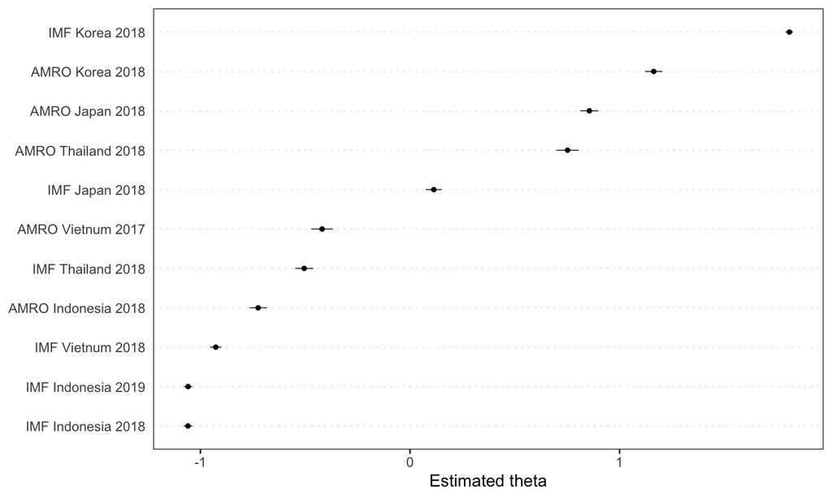

```r
textplot_scale1d(model_wf)
```

## Wordfish: 単語をプロット

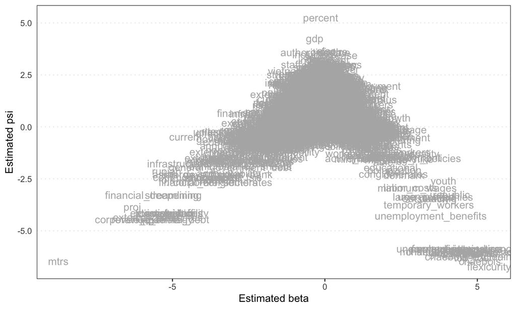

```r
textplot_scale1d(model_wf, margin = 'features')
```

## Wordfish: 単語テーブル

```r
coefs <- coefficients(model_wf)$features %>%
  as.data.frame() %>% rownames_to_column(var = "feature") %>%
  mutate_at(2:3, round, digits = 3) %>% arrange(-beta)
datatable(coefs)
```

|  | feature | beta | psi |
| --- | --- | --- | --- |
| 1 | flexicurity | 5.39 | -6.717 |
| 2 | chaebols | 5.085 | -6.46 |
| 3 | top_four | 4.865 | -6.279 |
| 4 | chaebols_excluding | 4.802 | -6.228 |
| 5 | moel | 4.665 | -6.118 |
| 6 | college | 4.589 | -6.059 |
| 7 | orbis | 4.589 | -6.059 |
| 8 | gvc_integration | 4.589 | -6.059 |
| 9 | top_chaebols | 4.589 | -6.059 |
| 10 | banerji_et_al | 4.589 | -6.059 |

[output cut: 2472 more lines]

## おまけ: word vector training

Word embedding (word vector)は、最近よく使われるメソッドで、文脈の分析から単語をベクトルに落とし込む。このベクトルが多次元空間での意味を構成し、類似語を探したり、ベクトルの加算・減算で単語間の関係を探索したりできる。

**King - Man + Women = ?**

レビューペーパー:

- Spirling, A., & Rodriguez, P. L. (2019). Word Embeddings: What works, what doesn’t, and how to tell the difference for applied research, 1–51.

政治学や社会科学への応用例の代表的なものは:

- Rheault, L., & Cochrane, C. (2019). Word Embeddings for the Analysis of Ideological Placement in Parliamentary Corpora. *Political Analysis*, 1–22.
- Rodman, E. (2019). A Timely Intervention: Tracking the Changing Meanings of Political Concepts with Word Vectors. *Political Analysis*, 1–25.
- Garg, N., Schiebinger, L., Jurafsky, D., & Zou, J. (2018). Word embeddings quantify 100 years of gender and ethnic stereotypes. *Proceedings of the National Academy of Sciences*, *115*(16), E3635–E3644.

## gloveの推定

我々のコーパスを使って、Gloveを推定してみる。Gloveは単語のローカルな重み付き共起関係を用いて、ベクトルを推定する。通常は大きめのコーパスがないと、うまく動かない事が多いとされているので、今回の結果の信頼性は明らかではない。

```r
# tokensの最終形をテキストに戻す
data_text <- data_tokens_final %>% lapply(paste, collapse = " ") %>%
  lapply(stri_trans_tolower) %>% # 小文字に変換
  unlist()

# https://cran.rstudio.com/web/packages/text2vec/vignettes/glove.htmlを参考
# だた、色々動かないので注意
library(text2vec)

tokens <- space_tokenizer(data_text)
it = itoken(tokens, progressbar = FALSE)
vocab <- create_vocabulary(it)
vocab <- prune_vocabulary(vocab, term_count_min = 5L)
vectorizer <- vocab_vectorizer(vocab)
tcm <- create_tcm(it, vectorizer, skip_grams_window = 5L)

glove <- GlobalVectors$new(word_vectors_size = 50,
                           vocabulary = vocab,
                           x_max = 10)
glove$fit_transform(tcm, n_iter = 100) # 普通は20回も繰り返せばいい
```

[output not shown]

[output cut: 45 more lines]

[output not shown]

[output not shown]

[output cut: 25946 more lines]

[output not shown]

```r
word_vectors <- glove$components %>% t
```

## 類似語チェック

```r
words <- c("currency", "inflation", "growth", "investment")

for (wd in words) {
  cos_sim <- sim2(x = word_vectors,
                  y = word_vectors[wd, , drop = FALSE],
                  method = "cosine", norm = "l2")
cat("Base:", wd, "\n")
print(sort(cos_sim[,1], decreasing = TRUE)[2:6])
cat("\n")
}
```

```
## Base: currency
##          keep deteriorating      chaebols       amended    nationwide
##     0.4902205     0.4635549     0.4318583     0.4232014     0.4171981
##
## Base: inflation
## variables  reaching practices integrity   conduct
## 0.4396370 0.4023206 0.3771991 0.3618739 0.3575567
##
## Base: growth
##   increase       real      chile impairment     demand
##  0.4511924  0.3903658  0.3750981  0.3576013  0.3554405
##
## Base: investment
##   budgetary    consists      houses     subdued accelerated
##   0.4110478   0.3832917   0.3659068   0.3642879   0.3606126
```

## 類似語チェック

```r
words <- c("capital", "capitalization", "autonomy")

for (wd in words) {
  cos_sim <- sim2(x = word_vectors,
                  y = word_vectors[wd, , drop = FALSE],
                  method = "cosine", norm = "l2")
cat("Base:", wd, "\n")
print(sort(cos_sim[,1], decreasing = TRUE)[2:6])
cat("\n")
}
```

```
## Base: capital
##       asset     explain   mortality restrictive  investment
##   0.3813685   0.3710476   0.3626455   0.3564671   0.3508546
##
## Base: capitalization
##     volatility intermediation       internet         degree   reclassified
##      0.4710671      0.4703202      0.4594273      0.4515631      0.4483434
##
## Base: autonomy
## nonfinancial      prudent      involve    converted         save
##    0.4685614    0.4609604    0.4408311    0.4311453    0.4292758
```